# Getting started with R

This notebook contains the answers to Task 2: Classification: Predict which Brand of Products Customers Prefer.

```r
library(readr)
library(caret)
library(ggplot2)
library(dplyr)
```

```r
train_df<- read.csv("CompleteResponses.csv")#Clients who included their favorite computer brand in the questionaire answers
test_df<- read.csv("SurveyIncomplete.csv") #Clients that did not favorite computer brand
train_df
```

| salary | age | elevel | car | zipcode | credit | brand |
| --- | --- | --- | --- | --- | --- | --- |
| 119806.54 | 45 | 0 | 14 | 4 | 442037.711 | 0 |
| 106880.48 | 63 | 1 | 11 | 6 | 45007.179 | 1 |
| 78020.75 | 23 | 0 | 15 | 2 | 48795.323 | 0 |
| 63689.94 | 51 | 3 | 6 | 5 | 40888.877 | 1 |
| 50873.62 | 20 | 3 | 14 | 4 | 352951.498 | 0 |
| 130812.74 | 56 | 3 | 14 | 3 | 135943.022 | 1 |
| 136459.34 | 24 | 4 | 8 | 5 | 80500.564 | 1 |
| 103866.90 | 62 | 3 | 3 | 0 | 359803.894 | 1 |
| 72298.80 | 29 | 4 | 17 | 0 | 276298.695 | 0 |
| 37803.33 | 41 | 1 | 5 | 4 | 493219.269 | 1 |

[output cut: 990 more lines]

```r
test_df
```

| salary | age | elevel | car | zipcode | credit | brand |
| --- | --- | --- | --- | --- | --- | --- |
| 150000.00 | 76 | 1 | 3 | 3 | 377980.102 | 1 |
| 82523.84 | 51 | 1 | 8 | 3 | 141657.607 | 0 |
| 115646.64 | 34 | 0 | 10 | 2 | 360980.358 | 1 |
| 141443.39 | 22 | 3 | 18 | 2 | 282736.319 | 1 |
| 149211.27 | 56 | 0 | 5 | 3 | 215667.290 | 1 |
| 46202.25 | 26 | 4 | 12 | 1 | 150419.396 | 1 |
| 125821.24 | 64 | 3 | 1 | 2 | 173429.385 | 1 |
| 20141.14 | 50 | 3 | 9 | 0 | 447716.535 | 1 |
| 135261.85 | 26 | 2 | 3 | 4 | 223821.219 | 1 |
| 83273.93 | 46 | 3 | 18 | 6 | 213961.368 | 0 |

[output cut: 990 more lines]

These are the two datasets to be used for this task. It’s worth noting that the column “brand” in the test_df contains either default or false information therefore it’s useless and should not be considered.

*Understand the data:*

```r
#print("List your attributes within your data set.")
#attributes(train_df)  # Too long
print("Prints the min, max, mean, median, and quartiles of each attribute.")
```

```
[1] "Prints the min, max, mean, median, and quartiles of each attribute."
```

```r
summary(train_df)
```

```
     salary            age            elevel           car           zipcode          credit           brand
 Min.   : 20000   Min.   :20.00   Min.   :0.000   Min.   : 1.00   Min.   :0.000   Min.   :     0   Min.   :0.0000
 1st Qu.: 52082   1st Qu.:35.00   1st Qu.:1.000   1st Qu.: 6.00   1st Qu.:2.000   1st Qu.:120807   1st Qu.:0.0000
 Median : 84950   Median :50.00   Median :2.000   Median :11.00   Median :4.000   Median :250607   Median :1.0000
 Mean   : 84871   Mean   :49.78   Mean   :1.983   Mean   :10.52   Mean   :4.041   Mean   :249176   Mean   :0.6217
 3rd Qu.:117162   3rd Qu.:65.00   3rd Qu.:3.000   3rd Qu.:15.75   3rd Qu.:6.000   3rd Qu.:374640   3rd Qu.:1.0000
 Max.   :150000   Max.   :80.00   Max.   :4.000   Max.   :20.00   Max.   :8.000   Max.   :500000   Max.   :1.0000
```

```r
print("Displays the structure of your data set.")
```

```
[1] "Displays the structure of your data set."
```

```r
str(train_df)
```

```
'data.frame':   9898 obs. of  7 variables:
 $ salary : num  119807 106880 78021 63690 50874 ...
 $ age    : int  45 63 23 51 20 56 24 62 29 41 ...
 $ elevel : int  0 1 0 3 3 3 4 3 4 1 ...
 $ car    : int  14 11 15 6 14 14 8 3 17 5 ...
 $ zipcode: int  4 6 2 5 4 3 5 0 0 4 ...
 $ credit : num  442038 45007 48795 40889 352951 ...
 $ brand  : int  0 1 0 1 0 1 1 1 0 1 ...
```

```r
print("Names your attributes within your data set.")
```

```
[1] "Names your attributes within your data set."
```

```r
names(train_df)
```

```
[1] "salary"  "age"     "elevel"  "car"     "zipcode" "credit"  "brand"
```

```r
#print("Will print out the instances within that particular column in your data set.")
#train_df$salary # Too long
#train_df$age  # Too long
```

```r
print("Prints the min, max, mean, median, and quartiles of each attribute.")
```

```
[1] "Prints the min, max, mean, median, and quartiles of each attribute."
```

```r
summary(test_df)
```

```
     salary            age            elevel           car          zipcode          credit           brand
 Min.   : 20000   Min.   :20.00   Min.   :0.000   Min.   : 1.0   Min.   :0.000   Min.   :     0   Min.   :0.0000
 1st Qu.: 52590   1st Qu.:35.00   1st Qu.:1.000   1st Qu.: 6.0   1st Qu.:2.000   1st Qu.:122311   1st Qu.:0.0000
 Median : 86221   Median :50.00   Median :2.000   Median :11.0   Median :4.000   Median :250974   Median :0.0000
 Mean   : 85794   Mean   :49.94   Mean   :2.009   Mean   :10.6   Mean   :4.038   Mean   :249546   Mean   :0.0126
 3rd Qu.:118535   3rd Qu.:65.00   3rd Qu.:3.000   3rd Qu.:16.0   3rd Qu.:6.000   3rd Qu.:375653   3rd Qu.:0.0000
 Max.   :150000   Max.   :80.00   Max.   :4.000   Max.   :20.0   Max.   :8.000   Max.   :500000   Max.   :1.0000
```

```r
print("Displays the structure of your data set.")
```

```
[1] "Displays the structure of your data set."
```

```r
str(test_df)
```

```
'data.frame':   5000 obs. of  7 variables:
 $ salary : num  150000 82524 115647 141443 149211 ...
 $ age    : int  76 51 34 22 56 26 64 50 26 46 ...
 $ elevel : int  1 1 0 3 0 4 3 3 2 3 ...
 $ car    : int  3 8 10 18 5 12 1 9 3 18 ...
 $ zipcode: int  3 3 2 2 3 1 2 0 4 6 ...
 $ credit : num  377980 141658 360980 282736 215667 ...
 $ brand  : int  1 0 1 1 1 1 1 1 1 0 ...
```

```r
print("Names your attributes within your data set.")
```

```
[1] "Names your attributes within your data set."
```

```r
names(test_df)
```

```
[1] "salary"  "age"     "elevel"  "car"     "zipcode" "credit"  "brand"
```

```r
#Convert categorical columns into factors to indicate that these columns contain a limited number of unique values.
train_df$elevel <- as.factor(train_df$elevel)
train_df$car <- as.factor(train_df$car)
train_df$zipcode <- as.factor(train_df$zipcode)
train_df$brand <- as.factor(train_df$brand)

sapply(train_df, typeof)
```

```
   salary       age    elevel       car   zipcode    credit     brand
 "double" "integer" "integer" "integer" "integer"  "double" "integer"
```

```r
sapply(train_df, typeof) == sapply(test_df, typeof)
```

```
 salary     age  elevel     car zipcode  credit   brand
   TRUE    TRUE    TRUE    TRUE    TRUE    TRUE    TRUE
```

Yes, they have the same data type. All columns are of numerical type so no adjustment needed here. In this project I will predict a nominal value, not a numerical one. Therefore I have to convert the target column (brand) into a factor. Otherwise caret would assume variable is continuous and would not make a binary classifier model.

I will do the same into the categorical features because as far as I investigated, categorical features should be factors, as these are not numerical and continuous, and consequently the final model will be better adjusted to reality and have a better performance.

```r
train_df$elevel <- as.factor(train_df$elevel)
train_df$car <- as.factor(train_df$car)
train_df$zipcode <- as.factor(train_df$zipcode)
test_df$brand <- as.factor(test_df$brand)
```

```r
any(is.na(train_df))
```

```
[1] FALSE
```

```r
any(is.na(test_df))
```

```
[1] FALSE
```

There are no missing values in any of the dataframes, thus the chunk below is unnecessary.

```r
#na.omit(DatasetName$ColumnName#Drops any rows with missing values and omits them forever.
#na.exclude(DatasetName$ColumnName)#Drops any rows with missing values, but keeps track of where they were.
#DatasetName$ColumnName[is.na(DatasetName$ColumnName)]<-mean(DatasetName$ColumnName,na.rm = TRUE) #Replace the missing values with the mean
```

*Exploratory Data Analysis*

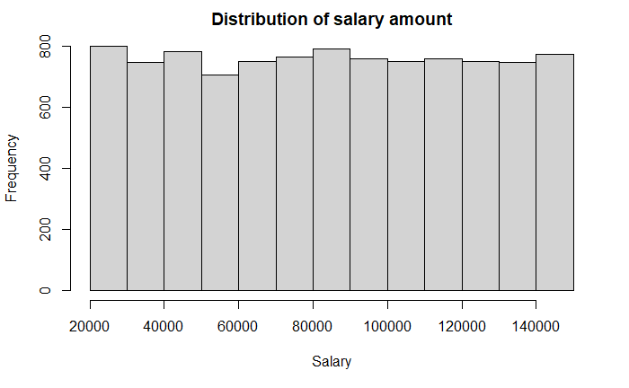

```r
#Salary
hist(train_df$salary,xlab="Salary",main="Distribution of salary amount")
```

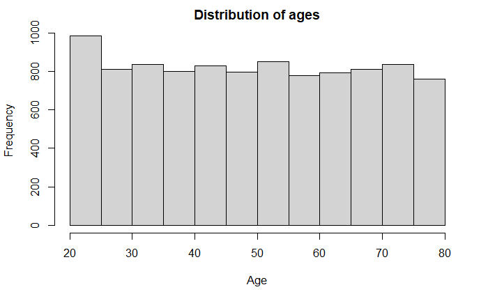

```r
#Age
hist(train_df$age,xlab="Age",main="Distribution of ages")
```

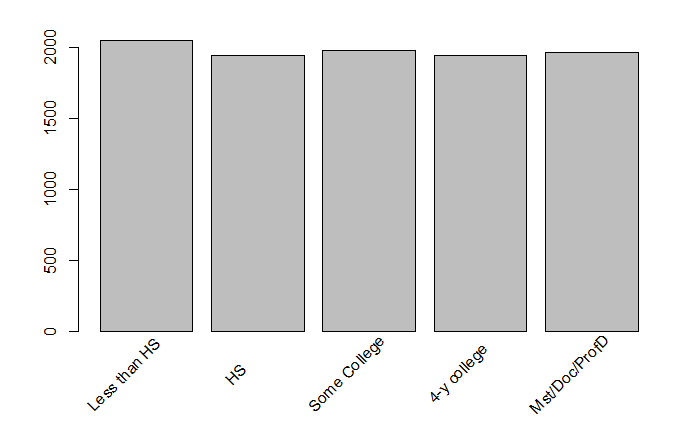

```r
#Education
x<-barplot(table(train_df$elevel), xaxt="n")
text(cex=1, x=x-.25, y=-300, c('Less than HS', 'HS','Some College','4-y college','Mst/Doc/ProfD'), xpd=TRUE, srt=45)
```

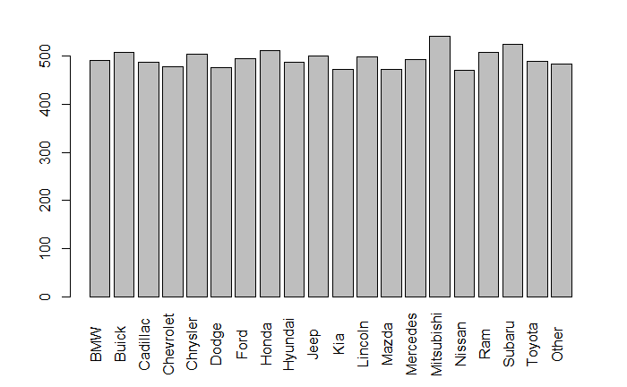

```r
#Car
x<-barplot(table(train_df$car), xaxt="n")
text(cex=1, x=x-.25, y=-100, c('BMW','Buick','Cadillac','Chevrolet','Chrysler','Dodge','Ford','Honda','Hyundai','Jeep','Kia','Lincoln','Mazda','Mercedes','Mitsubishi','Nissan','Ram','Subaru','Toyota','Other'), xpd=TRUE, srt=90)
```

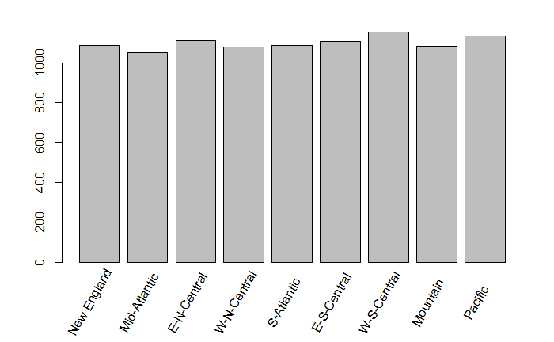

```r
#Zip Code
x<-barplot(table(train_df$zipcode), xaxt="n")
text(cex=1, x=x-.25, y=-200, c('New England','Mid-Atlantic','E-N-Central','W-N-Central','S-Atlantic','E-S-Central','W-S-Central','Mountain','Pacific'), xpd=TRUE, srt=60)
```

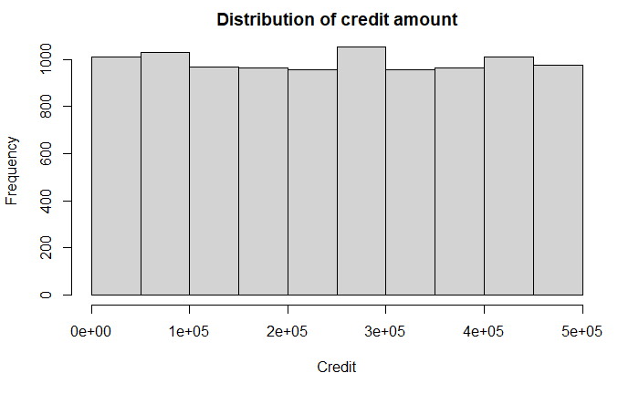

```r
#Credit
hist(train_df$credit,xlab="Credit",main="Distribution of credit amount")
```

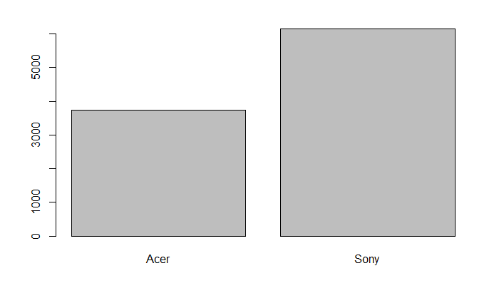

```r
#Computer Brand
barplot(table(train_df$brand),names.arg = c('Acer','Sony'))
```

Looking at the distributions above, all variables seem to be quite uniformly distributed. Nothing to point out in the independent variables.

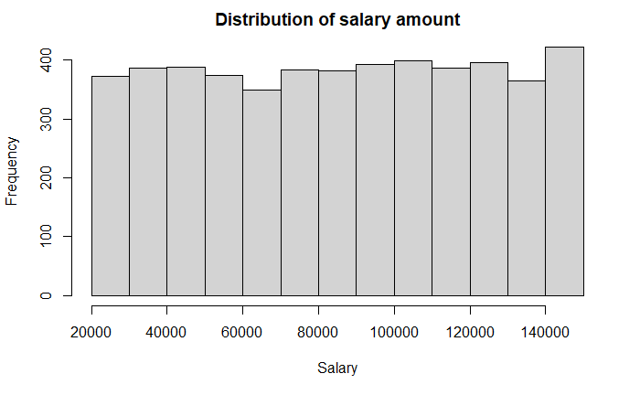

```r
#Salary
hist(test_df$salary,xlab="Salary",main="Distribution of salary amount")
```

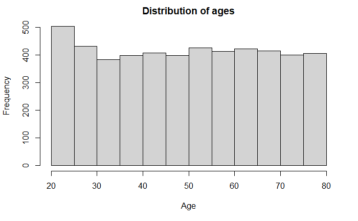

```r
#Age
hist(test_df$age,xlab="Age",main="Distribution of ages")
```

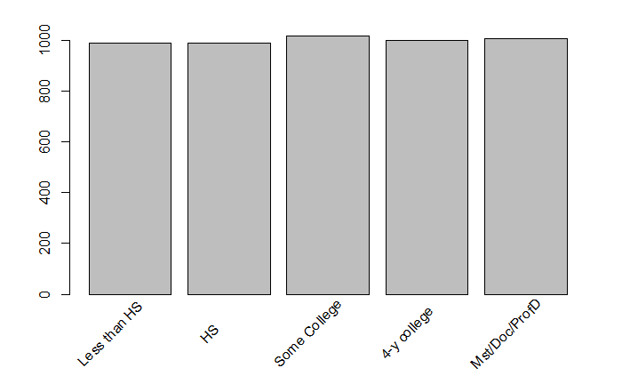

```r
#Education
x<-barplot(table(test_df$elevel), xaxt="n")
text(cex=1, x=x-.25, y=-150, c('Less than HS', 'HS','Some College','4-y college','Mst/Doc/ProfD'), xpd=TRUE, srt=45)
```

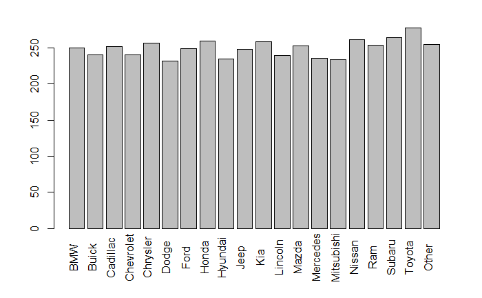

```r
#Car
x<-barplot(table(test_df$car), xaxt="n")
text(cex=1, x=x-.25, y=-40, c('BMW','Buick','Cadillac','Chevrolet','Chrysler','Dodge','Ford','Honda','Hyundai','Jeep','Kia','Lincoln','Mazda','Mercedes','Mitsubishi','Nissan','Ram','Subaru','Toyota','Other'), xpd=TRUE, srt=90)
```

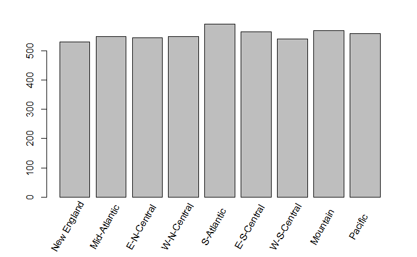

```r
#Zip Code
x<-barplot(table(test_df$zipcode), xaxt="n")
text(cex=1, x=x-.25, y=-100, c('New England','Mid-Atlantic','E-N-Central','W-N-Central','S-Atlantic','E-S-Central','W-S-Central','Mountain','Pacific'), xpd=TRUE, srt=60)
```

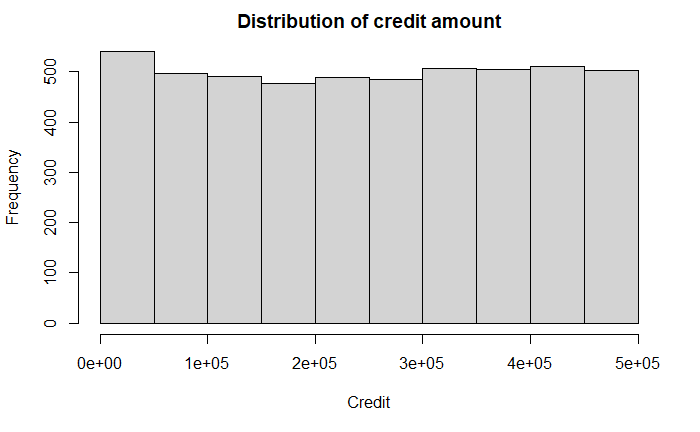

```r
#Credit
hist(test_df$credit,xlab="Credit",main="Distribution of credit amount")
```

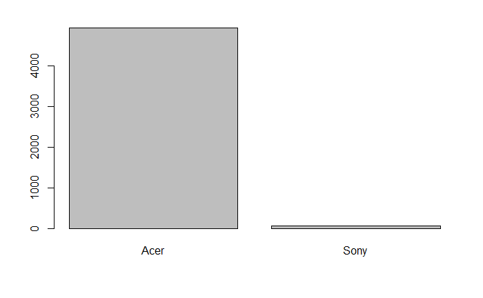

```r
#Computer Brand
barplot(table(test_df$brand),names.arg = c('Acer','Sony'))
```

The distribution of variables seem to be quite uniformly distributed. Once again, the target column stands out, because in the test dataset this column is faulty and is filled with 0 by default. Apart from the column “brand”, both train and test datasets have quite similar characteristics.

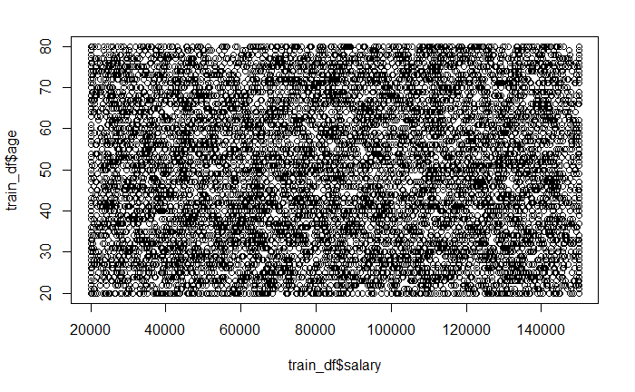

```r
plot(train_df$salary,train_df$age)
```

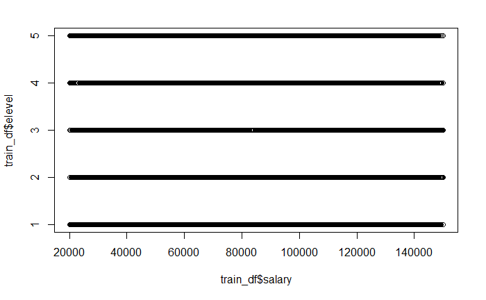

```r
plot(train_df$salary,train_df$elevel)
```

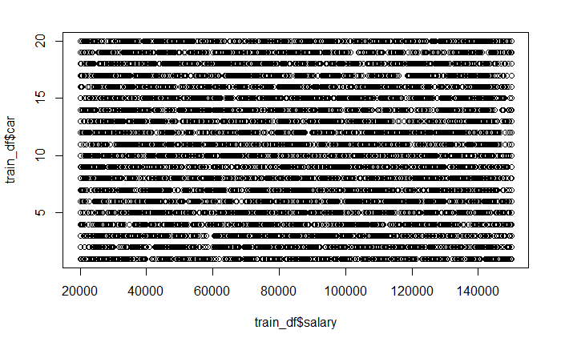

```r
plot(train_df$salary,train_df$car)
```

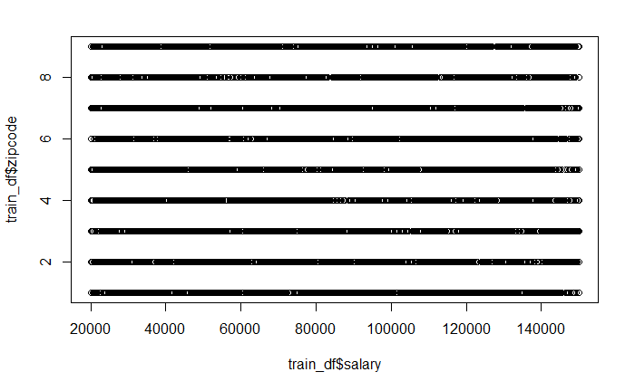

```r
plot(train_df$salary,train_df$zipcode)
```

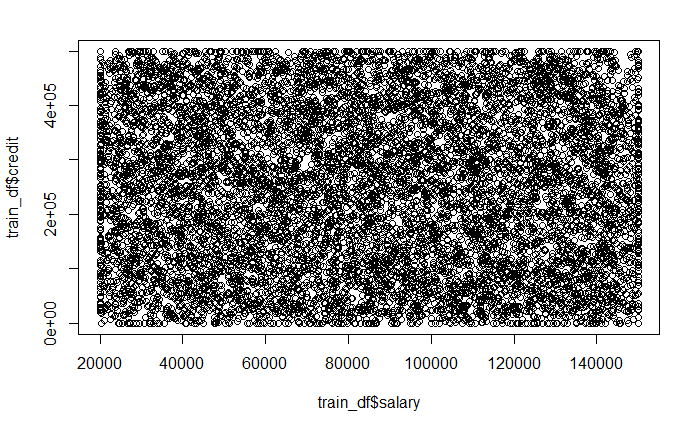

```r
plot(train_df$salary,train_df$credit)
```

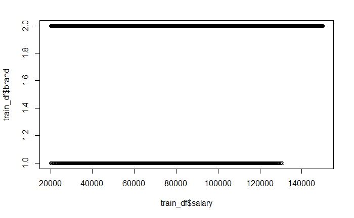

```r
plot(train_df$salary,train_df$brand)
```

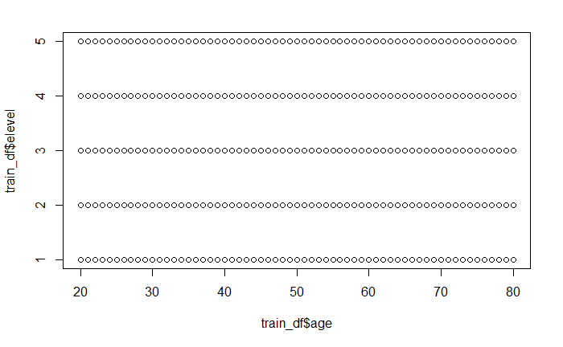

```r
plot(train_df$age,train_df$elevel)
```

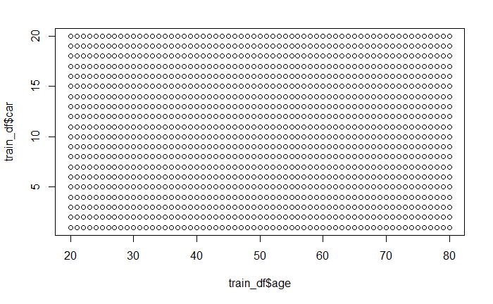

```r
plot(train_df$age,train_df$car)
```

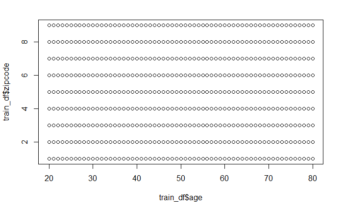

```r
plot(train_df$age,train_df$zipcode)
```

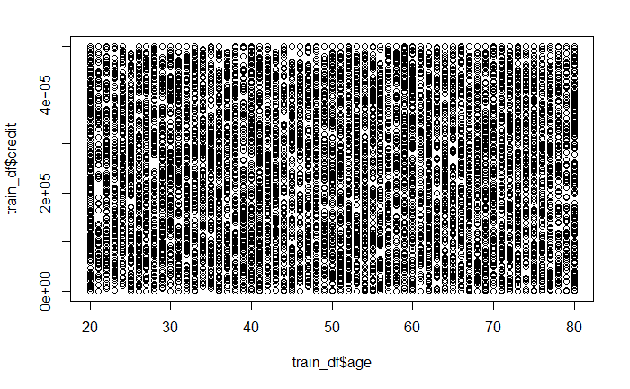

```r
plot(train_df$age,train_df$credit)
```